# Outliers_set_New_var_FDR5perc_top1perc_BF10

Thomas Francisco

2024-04-30

This script will enable to visualize and choose the set of outliers loci that will be used to compute genomic offset. To select the candidates SNPs, we performed 5 GEA methods in order to detect SNPs potentially linked with climatic variables: - RDA: Redundancy analysis. It’s a linear multivariate methods (multivariate for response and explanatory variables) that do not account for population structure. It performs the analysis at the population level with allelic frequency data. - pRDA: Partial Redundancy analysis. It’s an extension of the RDA accounting for population structure. As proxy of population structure, we used the PCs axis of a genetic PCA. It performs the analysis at the population level with allelic frequency data. - BAYPASS: It’s also a linear models accounting for population structure, univariate because it does consider explanatory variables one by one. The proxy of population structure is an omega matrix of genetic variation between populations using the core model of BAYPASS. It performs the analysis at the population level with data of the allele count at the population level. - LFMM: latent factor mixte model: it’s a linear multivariate model: all explanatory variables are studying together. It does correct for population structure by using latent factor (it’s very similar to what we found with genetic PCs). It perform the analysis at the individual level with allele count data. - GF: it’s a non linear model based on machine learning. It does not correct for population structure and it’s a multivariate analysis. snp per snp but all climatic variables together. Nevertheless, we can try to correct by population structure but it did not work well. It performs the analysis at the population level with allelic frequency data (the corrected version used the indiv level because it used the corrected genomic matrix from LFMM)

Each of these methods provide a set of candidate SNPs. To select our outliers, we will only retained from these candidates, SNP identified by at least 2 methods and not in too LD. In this script, we will select outliers based on the most conservatives thresholds set with FDR < 5%, Top 1% and BF > 10.

```
1. Load the candidates SNPs
```

```r
#names of the files
list_data <- c("outliers_RDA_FDR5perc_T_Adapcon_gentree","outliers_pRDA_FDR5perc_T_Adapcon_gentree","outliers_T_adapcon_gentree_BAYPASS_BF_10","outliers_T_adapcon_gentree_LFMM_5perc","outliers_rank_based_top1perc_GF_raw")

#name of the output
names_set <- c("RDA","pRDA","BAYPASS","LFMM","GF")

#load data
for(x in 1:5){
  set <- list_data[x]
  load(paste0("C:/Users/tfrancisco/Documents/Thèse/Results/species/taxus/GEA_new_var/outliers/",set,".Rdata"))
  name <- names_set[x]
assign(paste0(name,"_set"),get(set))
}
```

We need to put every set into a list

```r
#list of candidates
list_candidates<-list(RDA=RDA_set[,1],pRDA=pRDA_set[,1],BAYPASS=BAYPASS_set[,1],LFMM=LFMM_set[,1],GF=GF_set)
```

we can represent in a venn diagram to visualize the overlapping candidates

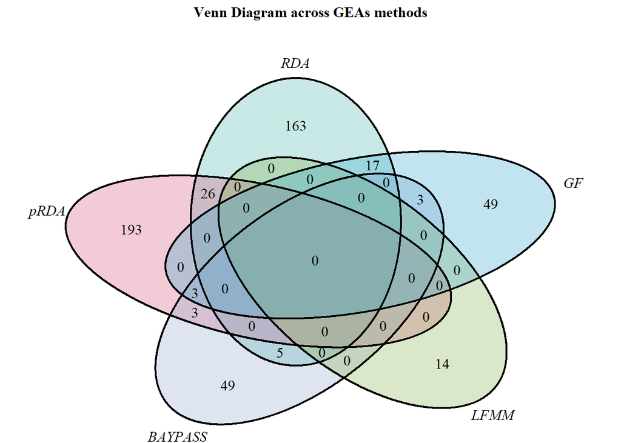

```r
grid.newpage()
ven <- venn.diagram(x = list_candidates,
        category.names = c("RDA" ,"pRDA","BAYPASS","LFMM","GF"),
        filename = NULL,fill = c("#45B6AA","#D45176","#91A6CE","#86AD4C","#33A5CE"),
alpha = 0.30,print.mode=c("raw"),margin = 0.1,  # Adjust the margins
                    cat.fontface = "italic",  # Optional: Make category names italic
                    cat.fontsize = 16,
                    main= "Venn Diagram across GEAs methods",
                    main.fontface = "bold")  # Optional: Adjust font size)
grid.draw(ven)
```

Now, we can make a dataframe with only the overlapping candidate of at least 2 methods:

```r
comm_RDA_pRDA <- data.frame(outliers=list_candidates[c("RDA","pRDA")] %>% Reduce(intersect, .))
comm_RDA_BAYPASS <- data.frame(outliers=list_candidates[c("RDA","BAYPASS")] %>% Reduce(intersect, .))
comm_RDA_GF <- data.frame(outliers=list_candidates[c("GF","RDA")] %>% Reduce(intersect, .))
comm_RDA_LFMM <- data.frame(outliers=list_candidates[c("LFMM","RDA")] %>% Reduce(intersect, .))
comm_pRDA_BAYPASS <- data.frame(outliers=list_candidates[c("pRDA","BAYPASS")] %>% Reduce(intersect, .))
comm_pRDA_GF <- data.frame(outliers=list_candidates[c("GF","pRDA")] %>% Reduce(intersect, .))
comm_pRDA_LFMM <- data.frame(outliers=list_candidates[c("LFMM","pRDA")] %>% Reduce(intersect, .))
comm_BAYPASS_GF <- data.frame(outliers=list_candidates[c("GF","BAYPASS")] %>% Reduce(intersect, .))
comm_BAYPASS_LFMM <- data.frame(outliers=list_candidates[c("LFMM","BAYPASS")] %>% Reduce(intersect, .))
comm_GF_LFMM <- data.frame(outliers=list_candidates[c("GF","LFMM")] %>% Reduce(intersect, .))


outliers_set <- data.frame(rbind(comm_RDA_pRDA,comm_RDA_BAYPASS,comm_RDA_GF,comm_RDA_LFMM,comm_pRDA_BAYPASS,comm_pRDA_GF,comm_pRDA_LFMM,comm_BAYPASS_GF,comm_BAYPASS_LFMM,comm_GF_LFMM)) %>% unique()
```

We can see that some of the outliers are located on the same contig. This can bias the signals by giving more power to regions of the genome with more outliers because they are in LD. It’s only an issues if we make the hypothesis that the number of SNPs per contig is not size dependent and then some contigs can be over represented due to stochastic events and then their signals could be inflated. Due to that, we only remove the SNPs in LD with other SNPs on the same contig.

Steps to remove the SNPs in LD on the same contig.

Linkage desequilibrium

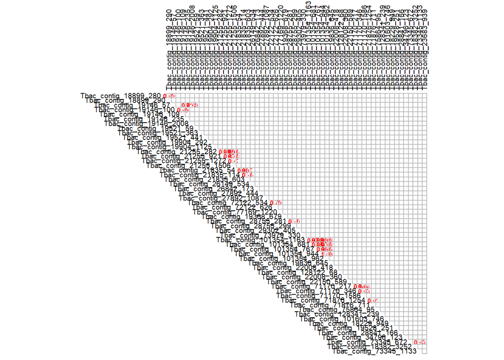

```r
#load genotypic data at the individual level
load("C:/Users/tfrancisco/Documents/Thèse/Data/Espèces/Taxus_baccata/genetic_new/GEA/vcf_data_GEA.Rdata")
genomic_matrix_LD <- vcf_data_GEA


#subset the genomic matrix to only the outliers
candidates_to_LD <- data.frame(genomic_matrix_LD[outliers_set$outliers])

#put the data into the right format
genotypic_data<- makeGenotypes(candidates_to_LD)

#RUN the LD calculation
LD_estimate <- LD(genotypic_data)

#save the R² values
matrix_LD <- LD_estimate$`R^2`
matrix_LD_format<- matrix_LD[,-1] #remove the first row

#filtered the LD to only take LD lower than -0.7 or above 0.7
matrix_ld_filtered <- matrix_LD_format
matrix_ld_filtered[abs(matrix_LD_format) < 0.7] <- 0

# Plot the modified LD matrix using corrplot
corrplot(matrix_ld_filtered, method = "number", addrect = 2, col = c("red","white", "red"), type = "upper", tl.col = "black", tl.cex = 0.6, number.cex = 0.5, cl.pos="n")
```

```r
# Save in a dataframe the SNP with LD above 0.7
LD0.7<- which(matrix_LD_format > 0.7 & matrix_LD_format, arr.ind = TRUE)

# Create a dataframe to retain snp in LD with others
LD_df <- data.frame(
  snp_names_1 = rownames(matrix_LD_format)[LD0.7[, 1]],
  snp_names_2 = colnames(matrix_LD_format)[LD0.7[, 2]],
  LD = matrix_LD_format[LD0.7]
)

#create a new column contig and remove the rows where the SNPs in LD are in different contigs
LD_df_contig_bis <- LD_df %>%
  mutate(contig1 = sub("_[^_]*$", "", snp_names_1)) %>%
  mutate(contig2 = sub("_[^_]*$", "", snp_names_2))%>%
  filter(contig1 == contig2)

nrow(LD_df)-nrow(LD_df_contig_bis)
```

```
## [1] 0
```

0 Candidates were in LD with SNPs located on other contigs.

Now that we have a list of the LD association between SNPs, we can process to removed the SNPs in LD with the weaker signal: the ones with the weaker pvalues from RDA.

```r
#we need to output the names of the outliers in LD to see their pvalues and keep the lowest ones
LD_snps <- data.frame(snp_names = c(LD_df$snp_names_1,LD_df$snp_names_2)) %>% unique()

#load pvalues RDA
load("C:/Users/tfrancisco/Documents/Thèse/Data/Espèces/Taxus_baccata/genetic_new/GEA_new_var/pvalues_RDA_snp.Rdata")


p_values_RDA_snp_1 <- merge(LD_snps, pvalues_RDA_snp,"snp_names"); colnames(p_values_RDA_snp_1)=c("snp_names_1","pvalues_1")
p_values_RDA_snp_2 <- merge(LD_snps, pvalues_RDA_snp,"snp_names"); colnames(p_values_RDA_snp_2)=c("snp_names_2","pvalues_2")

pval_final_1 <- merge(LD_df_contig_bis,p_values_RDA_snp_1,"snp_names_1")
pval_final_2 <- merge(LD_df_contig_bis,p_values_RDA_snp_2,"snp_names_2")


pval_merge <- cbind(pval_final_1,pval_final_2[,4])

pval_merge_final <- pval_merge[,c(1,4,2,5)]; colnames(pval_merge_final) <- c("snp_names_1","pvalues_1","snp_names_2","pvalues_2")

pval_merge_final$worst_snp <- ifelse(pval_merge_final$pvalues_1 > pval_merge_final$pvalues_2, pval_merge_final$snp_names_1, pval_merge_final$snp_names_2) #select the snp with the farest pvalues from 0 (the weakest signal)

#snp to remove
SNP_to_remove <- pval_merge_final$worst_snp %>% unique()
nrow(data.frame(SNP_to_remove))
```

```
## [1] 19
```

Based on a LD of 0.7, we removed 19 SNPs.

Final dataset without the snp in LD with the weakest signal

```r
outliers_set_final_overlapping_no_LD_new_var <- outliers_set[!(outliers_set$outliers %in% SNP_to_remove),]
nrow(outliers_set_final_overlapping_no_LD_new_var%>% as.data.frame)
```

```
## [1] 38
```